[dblogr/](https://derekmichaelwright.github.io/dblogr)

# dblogr

The Personal website for Derek Michael Wright

> derekmichaelwright.github.io/dblogr/
> - Packages
> - Publications
> - Academic
> - agData
> - Blog
> - Photography

# About Me

**Derek Michael Wright**

I was born in Regina, Saskatchewan and graduated with a **BSc in Biology** from the [*University of Regina*](https://www.uregina.ca/) in 2012, followed by a **MSc in Agrobiotechnology** from [*Justus-Liebig-Universität Gießen*](https://www.uni-giessen.de/) (*University of Giessen, Germany*) in 2015. I now work in the Plant Sciences department at the [*University of Saskatchewan*](https://www.usask.ca/) and have been involved in four research projects ([**AGILE**](https://knowpulse.usask.ca/study/2675314), [**EVOLVES**](https://knowpulse.usask.ca/study/2691111), [**P2IRC**](https://p2irc.usask.ca/index.php) & [**ACTIVATE**](https://activating-crops.usask.ca/)) with **lentil** (*Lens culinaris*).

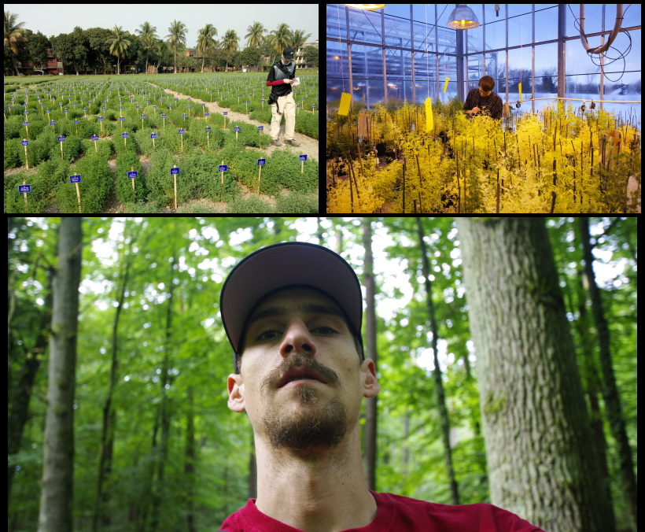

**My Curriculum Vitae (CV)**

- HTML version
- [PDF Version](https://github.com/derekmichaelwright/dblogr/raw/main/cv/cv.derek.m.wright.pdf)

**Emails**

- wrightmderek@gmail.com
- derek.wright@usask.ca

**Academic Work**

- [All Publications](https://derekmichaelwright.github.io/dblogr/publications/)
- Packages
- github.com/derekmichaelwright

**Socials**

- [twitter.com/DerekMWright](https://x.com/DerekMWright)
- instagram.com/derekmichaelwright/

# Packages

## Data Analysis & Visualization

### Package “gwaspr”

**gwaspr**: An package for plotting GWAS results from the `GAPIT` package

Install: `devtools::install_github("derekmichaelwright/gwaspr")`

Documentation:

- https://derekmichaelwright.github.io/gwaspr/
- https://github.com/derekmichaelwright/gwaspr/

Tutorials & Vignettes:

- GWAS Tutorial

[figure not shown]

### Package “agData”

**agData**: An package containing agricultural Data sets

Install: `devtools::install_github("derekmichaelwright/agData")`

Documentation:

- https://derekmichaelwright.github.io/agData/
- https://github.com/derekmichaelwright/agData/

Tutorials & Vignettes:

- https://derekmichaelwright.github.io/dblogr/#agdata

[figure not shown]

### Package “cypher”

**cypher**: An package for coding and decoding secret messages

Install: `devtools::install_github("derekmichaelwright/cypher")`

Documentation:

- https://derekmichaelwright.github.io/cypher/
- https://github.com/derekmichaelwright/cypher/

Tutorials & Vignettes:

- [Shiny App (R Script)](https://github.com/derekmichaelwright/cypher/blob/master/shinyapp/app.R)

[figure not shown]

# Publications

## Scientific Research

> - [All Publications](https://derekmichaelwright.github.io/dblogr/publications/)

Scientific publications I have been involved in while working/studying at [*University of Regina*](https://www.uregina.ca/), [*Justus-Liebig-Universität Gießen (University of Giessen)*](https://www.uni-giessen.de/) & the [*University of Saskatchewan*](https://www.usask.ca/).

### LDP Phenology

**Derek M. Wright**, Sandesh Neupane, Taryn Heidecker, Teketel A. Haile, Crystal Chan, Clarice J. Coyne, Rebecca J. McGee, Sripada Udupa, Fatima Henkrar, Eleonora Barilli, Diego Rubiales, Tania Gioia, Giuseppina Logozzo, Stefania Marzario, Reena Mehra, Ashutosh Sarker, Rajeev Dhakal, Babul Anwar, Debashish Sarker, Albert Vandenberg & Kirstin E. Bett

- [*Plants, People, Planet*. (**2021**) 3(2): 171-181.](https://doi.org/10.1002/ppp3.10158)
- [Github Repository](https://github.com/derekmichaelwright/AGILE_LDP_Phenology)
- [Data](https://github.com/derekmichaelwright/AGILE_LDP_Phenology/tree/master/data)
- [R Script (HTML)](https://derekmichaelwright.github.io/AGILE_LDP_Phenology/Phenology_Vignette.html)
- [AGILE_LDP_Phenology (Shiny App)](https://derek-wright-usask.shinyapps.io/AGILE_LDP_Phenology/)
- [Predict DTF (Shiny App)](https://derek-wright-usask.shinyapps.io/AGILE_Predict_DTF/)
- [All Figures (HTML)](https://derekmichaelwright.github.io/AGILE_LDP_Phenology/README.html)
- [All Figures (pdf)](https://github.com/derekmichaelwright/AGILE_LDP_Phenology/blob/master/README.pdf)

[figure not shown]

**Tutorials & Vignettes**

- [Lentil Populations](https://derekmichaelwright.github.io/dblogr/academic/lentil_populations/)
- [EnvData](https://derekmichaelwright.github.io/dblogr/academic/envdata)
- [Thermal Time](https://derekmichaelwright.github.io/dblogr/academic/thermal_time/)
- [PCA Tutorial](https://derekmichaelwright.github.io/dblogr/academic/pca_tutorial/)
- [Correlation Coefficients](https://derekmichaelwright.github.io/dblogr/academic/correlation_coefficients/)

**News Articles**

- [**Genome Canada - Application of genomics to innovation in the lentil economy (AGILE)**](https://www.genomecanada.ca/en/application-genomics-innovation-lentil-economy-agile)
- [**Genome Prairie - AGILE Innovating the growth of lentils**](http://www.genomeprairie.ca/project/current/agile)
- [**Global Plant Council Blog - Lentils under the lens: Improving genetic diversity for sustainable food security**](http://blog.globalplantcouncil.org/research/lentils-under-the-lens/)
- [**The Western Producer - Genetics project provides foundation for new Canadian lentil varieties**](https://www.producer.com/2019/01/genetics-project-provides-foundation-for-new-canadian-lentil-varieties/)
- [**SeedWorld - USask Scientists Develop Model to Identify Best Lentils for Climate Change Impacts**](https://www.seedworld.com/usask-scientists-develop-model-to-identify-best-lentils-for-climate-change-impacts/)

### LDP GWAS Phenology

[**Focusing the GWAS Lens on days to flower using latent variable phenotypes derived from global multi-environment trials**](https://doi.org/10.1002/tpg2.20269). *The Plant Genome*. (**2022**) 16(1): e20269. doi.org/10.1002/tpg2.20269

Sandesh Neupane, **Derek M. Wright**, Raul O. Martinez, Jakob Butler, Jim L. Weller, Kirstin E. Bett

- [*The Plant Genome*. (**2022**) 16(1): e20269.](https://doi.org/10.1002/tpg2.20269)
- [Github Repository](https://github.com/derekmichaelwright/AGILE_LDP_GWAS_Phenology)
- [R Script (HTML)](https://derekmichaelwright.github.io/AGILE_LDP_GWAS_Phenology/GWAS_Phenology_Vignette.html)
- [All Figures (HTML)](https://derekmichaelwright.github.io/AGILE_LDP_GWAS_Phenology/README.html)
- [All Figures (pdf)](https://github.com/derekmichaelwright/AGILE_LDP_GWAS_Phenology/blob/master/README.pdf)
- [Field Lab Earth Podcast](http://fieldlabearth.libsyn.com/latent-variable-phenotypes-in-lentil-with-sandesh-neupane-and-derek-wright)

[figure not shown]

### LDP GWAS UAV

**Derek M Wright**, Sandesh Neupane, Steve Shirtlife, Tania Gioia, Giuseppina Logozzo, Stefania Marzario, Karsten M.E. Nielsen & Kirstin E Bett

- [*The Plant Phenome Journal*. (**2025**) 8(1): e70040.](https://doi.org/10.1002/ppj2.70040)
- [Github Repository](https://github.com/derekmichaelwright/AGILE_LDP_UAV)
- [R Script (HTML)](https://derekmichaelwright.github.io/AGILE_LDP_UAV/LDP_UAV_Vignette.html)
- [All Figures (HTML)](https://derekmichaelwright.github.io/AGILE_LDP_UAV/README.html)
- [All Figures (pdf)](https://github.com/derekmichaelwright/AGILE_LDP_UAV/blob/master/README.pdf)
- [P2IRC Conference](https://www.youtube.com/watch?v=FkjKaGJG7Xc&list=PLNqTYnctRQrkNKbRPBt6Z3Wb81Vq-rAum&index=11)

[figure not shown]

### LDP GWAS Protein

[**Breeding potential of cultivated lentil for increased protein and amino acid concentrations in the Northern Great Plains**](http://dx.doi.org/10.1002/csc2.70085). *Crop Science*. (**2025**) 65(3): e70085. doi.org/10.1002/csc2.70085

**Derek M. Wright**, Jiayi Hang, James D. House & Kirstin E. Bett

- *Crop Science*. (**2025**) 65(3): e70085.
- [Github Repository](https://github.com/derekmichaelwright/AGILE_LDP_Protein)
- [R Script (HTML)](https://derekmichaelwright.github.io/AGILE_LDP_Protein/LDP_Protein_Vignette.html)
- [All Figures (HTML)](https://derekmichaelwright.github.io/AGILE_LDP_Protein/README.html)
- [All Figures (pdf)](https://github.com/derekmichaelwright/AGILE_LDP_Protein/blob/master/README.pdf)

A follow up to:

[**Prediction of protein and amino acid contents in whole and ground lentils using near-infrared reflectance spectroscopy**](https://doi.org/10.1016/j.lwt.2022.113669). *LWT*. (**2022**) 165: 113669. doi.org/10.1016/j.lwt.2022.113669

Jiayi Hang, Da Shi, Jason Neufeld, Kirstin E. Bett & James D. House

- [*LWT*. (**2022**) 165: 113669.](https://doi.org/10.1016/j.lwt.2022.113669)

[figure not shown]

### LDP Nepal Phenology

[**Strategic Identification of New Genetic Diversity to Expand Lentil (*Lens culinaris* Medik.) Production (Using Nepal as an Example)**](https://doi.org/10.3390/agronomy11101933). *Agronomy*. (**2021**) 11(10): 1933. doi.org/10.3390/agronomy11101933

Sandesh Neupane, Rajeev Dhakal, **Derek M. Wright**, Deny K. Shrestha, Bishnu Dhakal & Kirstin E. Bett

- [*Agronomy*. (**2021**) 11(10): 1933.](https://doi.org/10.3390/agronomy11101933)
- [Github Repository](https://github.com/derekmichaelwright/AGILE_LDP_Nepal)
- [R Script (HTML)](https://derekmichaelwright.github.io/AGILE_LDP_Nepal/Phenology_Vignette.html)
- [All Figures (HTML)](https://derekmichaelwright.github.io/AGILE_LDP_Nepal/README.html)
- [All Figures (pdf)](https://github.com/derekmichaelwright/AGILE_LDP_Nepal/blob/master/README.pdf)

[figure not shown]

### Genomic Selection in Lentil

[**Genomic selection for lentil breeding: Empirical evidence**](https://doi.org/10.1002/tpg2.20002). *The Plant Genome*. (**2020**) 13(e20002): 1-15. doi.org/10.1002/tpg2.20002

Teketel A. Haile, Taryn Heidecker, **Derek M. Wright**, Sandesh Neupane, Larissa Ramsay, Albert Vandenberg & Kirstin E. Bett.

- [*The Plant Genome*. (**2020**) 13(e20002): 1-15.](https://doi.org/10.1002/tpg2.20002)

[figure not shown]

### Lentil Flavones

[**Mass Spectrometry-Based Untargeted Metabolomics Reveals the Importance of Glycosylated Flavones in Patterned Lentil Seed Coats**](https://doi/10.1021/acs.jafc.2c07844). *Journal of Agricultural and Food Chemistry*. (**2023**) 71(7): 3541–3549. doi.org/10.1021/acs.jafc.2c07844

Fatma M. Elessawy, **Derek M. Wright**, Albert Vandenberg, Anas El-Aneed & Randy W. Purves.

- [*Journal of Agricultural and Food Chemistry*. (**2023**) 71(7): 3541–3549.](https://doi/10.1021/acs.jafc.2c07844)

[figure not shown]

### Algae Grazers

[**Grazing preferences of three species of amoebae on cyanobacteria and green algae**](https://doi.org/10.1111/jeu.13018). *The Journal of Eukaryotic Microbiology*. (**2024**) e13018: 1-14. doi.org/10.1111/jeu.13018

Harold G. Weger, April K. Polasek, **Derek M. Wright**, Arun Damodaran, John Stavrinides

- [*The Journal of Eukaryotic Microbiology*. (**2024**) e13018: 1-14. doi.org/10.1111/jeu.13018](https://doi.org/10.1111/jeu.13018)

[figure not shown]

### NEU in Canola

**Influence of heterozygosity on nitrogen use efficiency in hybrid and purebred lines of *Brassica napus* (L.)**. *University of Giessen*. (**2015**) MSc. Thesis.

**Derek M. Wright**.

- MSc Thesis (MastersThesis.pdf)
- R Script (HTML)

[figure not shown]

# Academic

## Tutorials & Vignettes

### Tutorials

Tutorials in on how to perform various statistical and genetic analyses.

#### GWAS

**GWAS Tutorial with gwaspr**

An R tutorial on running genome-wide association studies (GWAS) with GAPIT and gwaspr

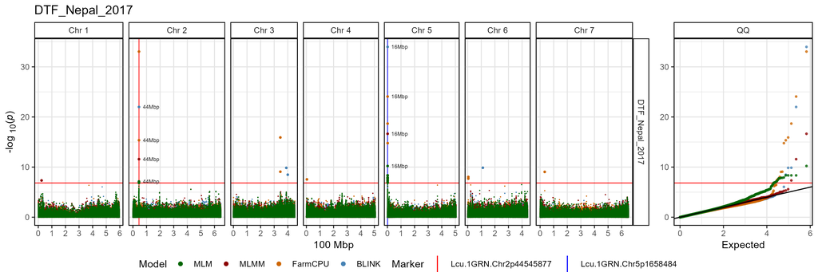

#### QTL

**QTL Tutorial with qtl2**

A tutorial on how to run QTL analyses in R with qtl2

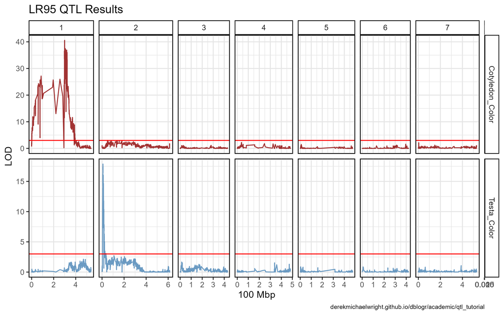

#### PCA

**PCA Tutorial**

A tutorial on how to run principal component analyses and heirarchical clustering in R

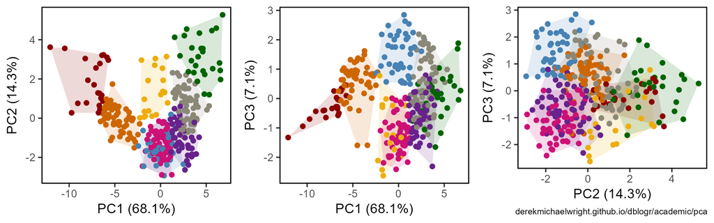

#### G x E

**G x E with Mixed Models**

A tutorial on how to run and assess genotype by environment interactions in R

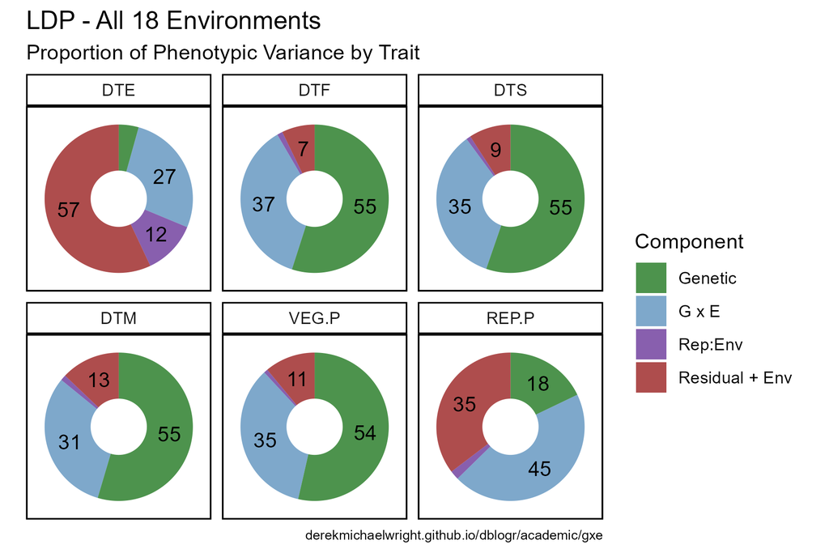

#### Heritability

**Calculating Heritability**

An R tutorial on how to calculate heritability

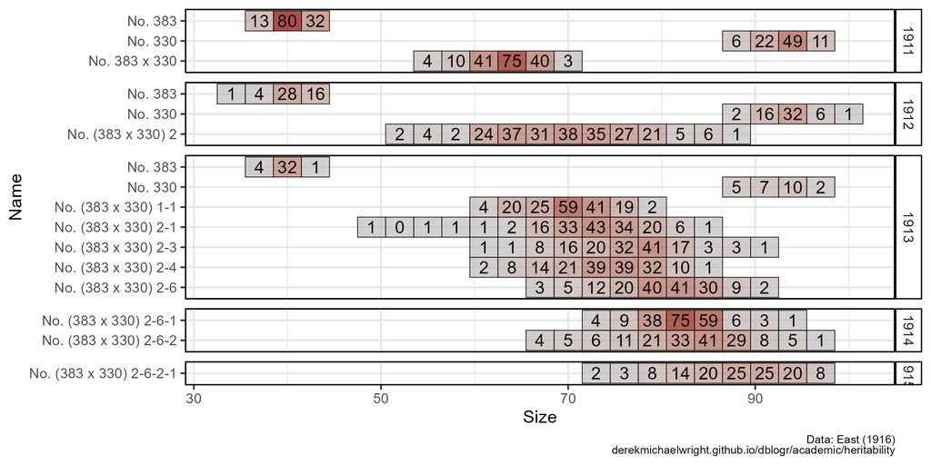

#### Augmented Designs

**Augmented Field Trial Designs**

An R tutorial on augmented field trial designs and how to adjust their values

**Note: Under Construction**

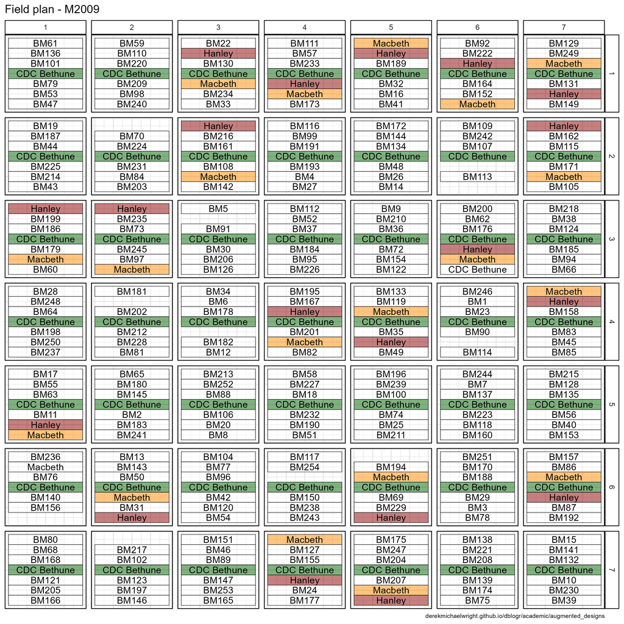

#### Correlation Coefficients and Predictive Models

**Correlation Coefficients and Predictive Models**

A vignette on how to properly use correlation coefficients when evaluating predictive models

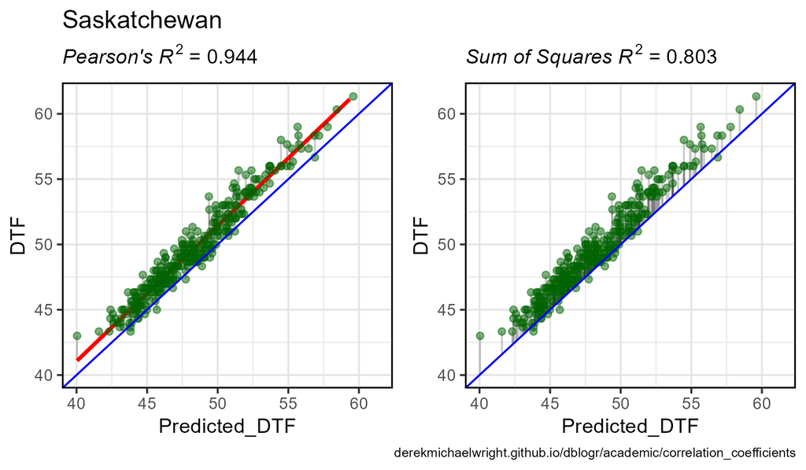

#### Dual Y-axis

**Dual Y-axis**

An R tutorial on how to create a plots with dual y-axes

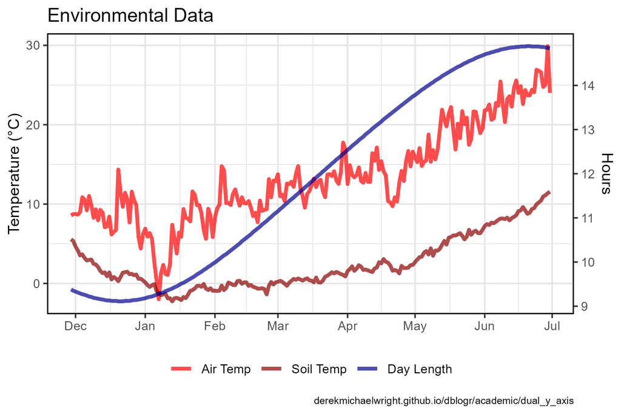

#### Thermal Time

**Calculating Thermal Time/Growing Degree Days**

An R tutorial on how to calculate thermal time and incorporate environmental data into a phenotype

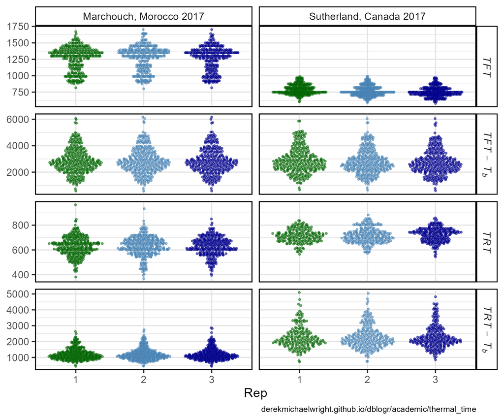

#### Environmental Data

**Environmental Data Tutorial**

An R tutorial on how to manipulate and plot environmental data

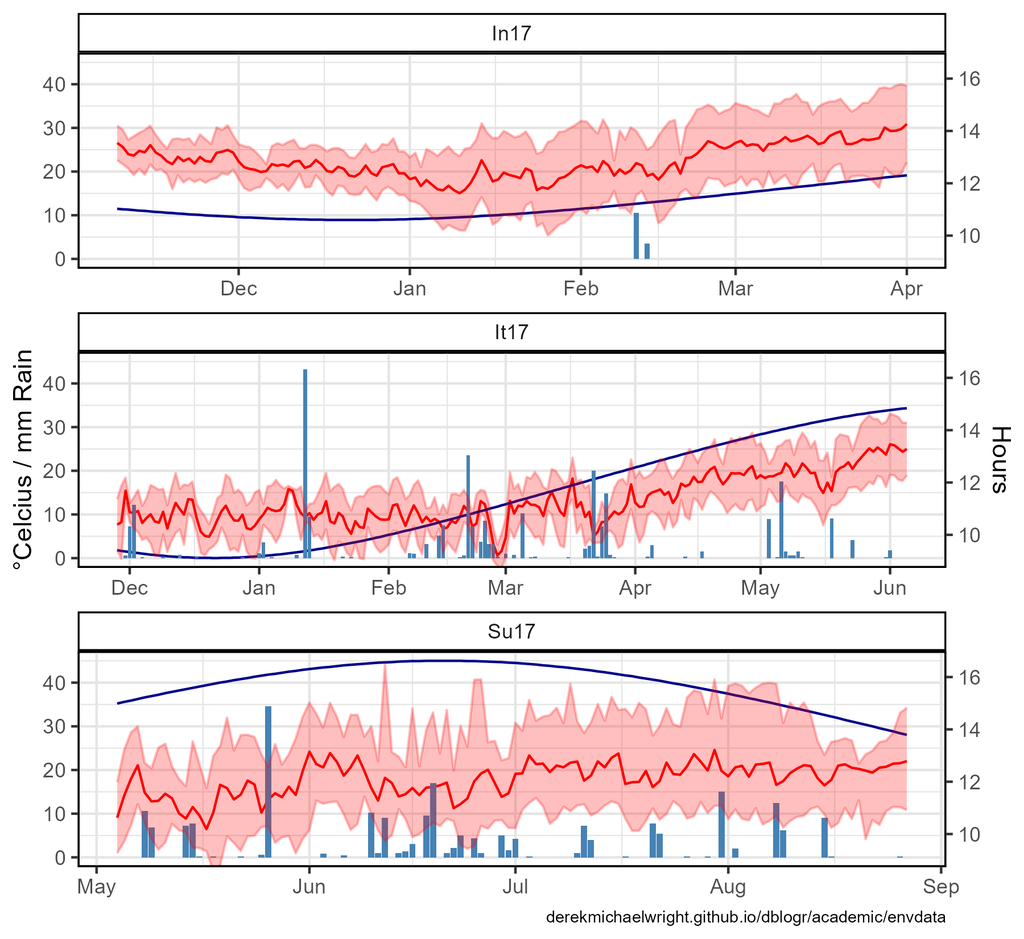

#### R Tutorial

**R Tutorial**

### Vignettes

Vignettes related to my work academic work and general science communication.

#### Data Visualizations

**Data Visualization**

A vignette illustrating different ways to visualize data

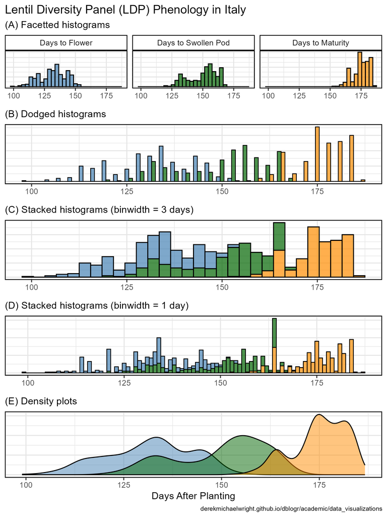

#### Misleading Graphs

**Misleading Graphs**

A vignette illustrating how to mislead with statistics and graphs

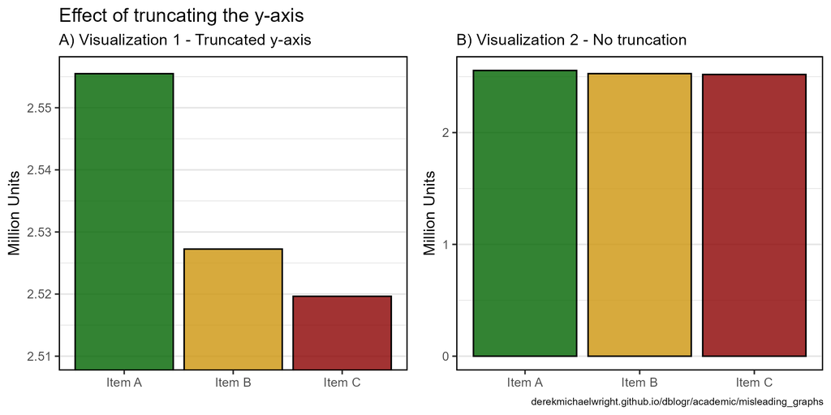

#### Lentil Research Populations

**Lentil Research Populations**

Graphs of different lentil populations representing their global genetic diversity

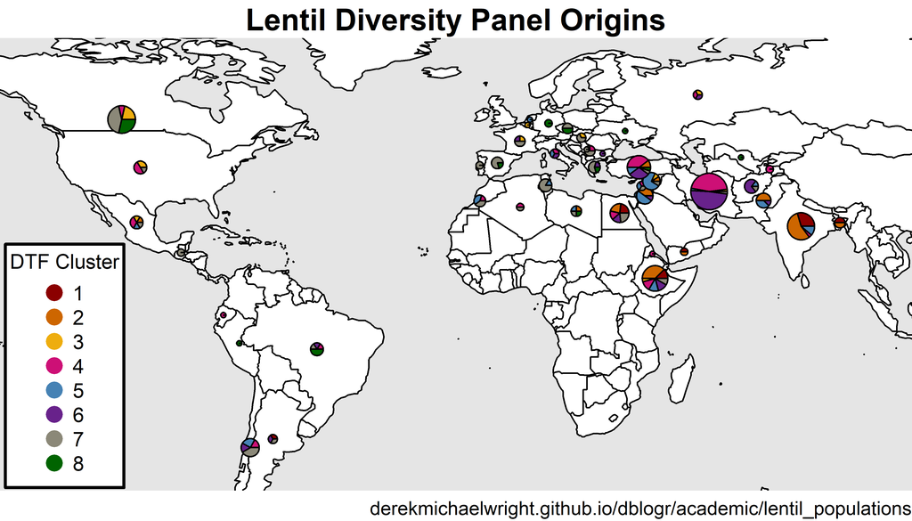

# agData

## Agricultural Data Sources

### FAOSTAT

#### Maps of Global Crop Production

**Maps of Global Crop Production**

Maps of crop production using FAO data

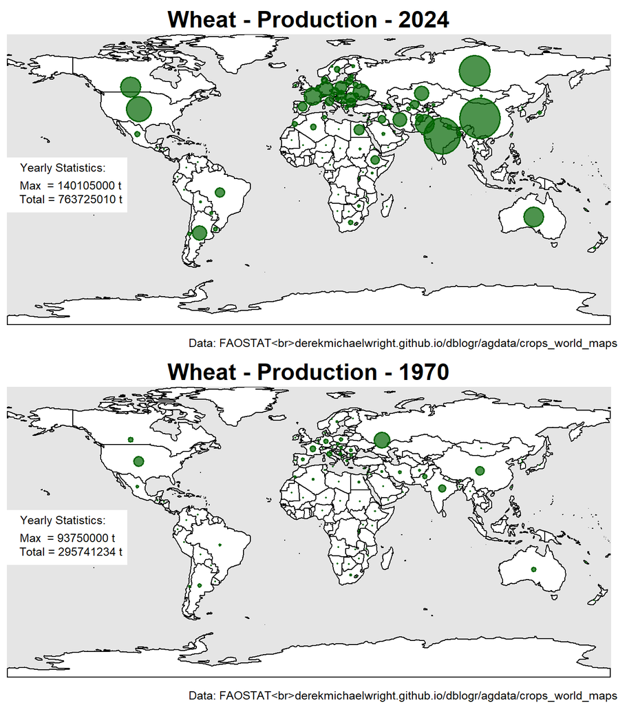

#### Global Farmland

**Global Agricultural Land Use**

Graphs of global agricultural land use with FAO data

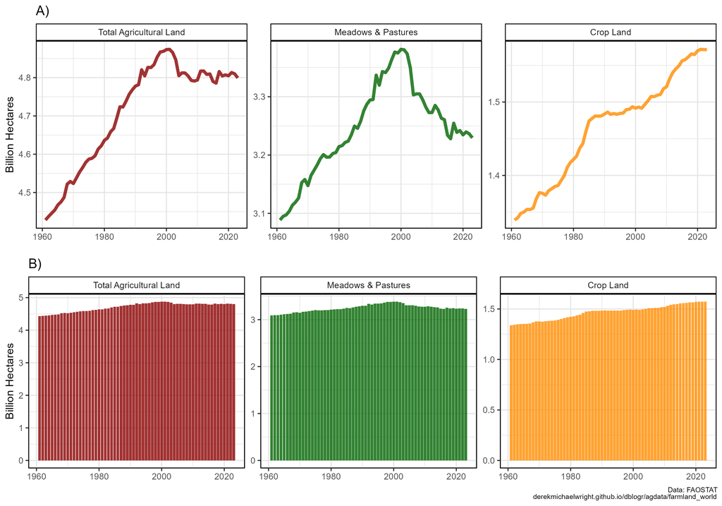

#### Global Food Security

**Global Food Security**

Graphs related to global food security using FAO data

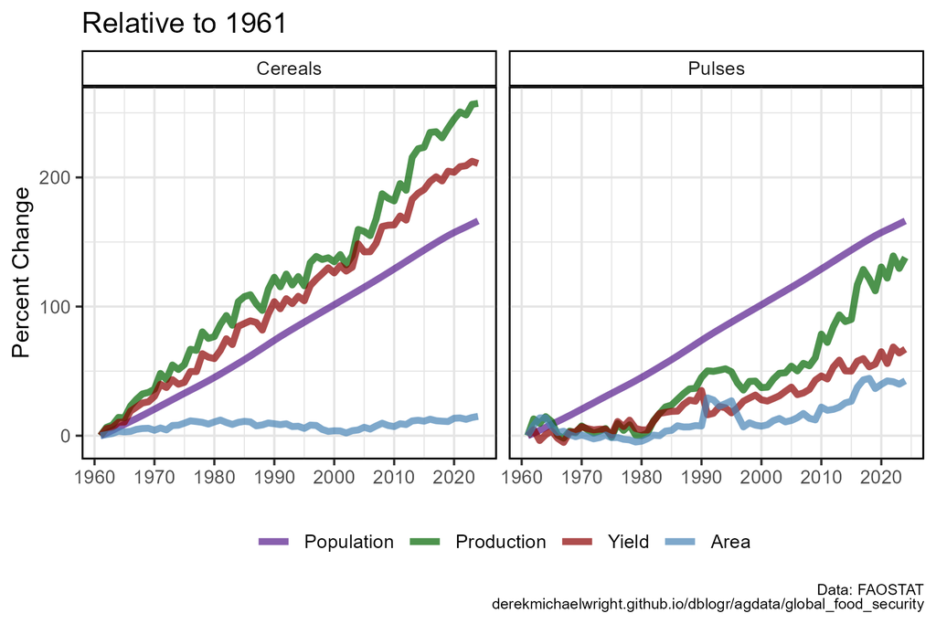

#### Import/Export by Area

**Import/Export by Area**

Graphs of of import/export by area using FAO data

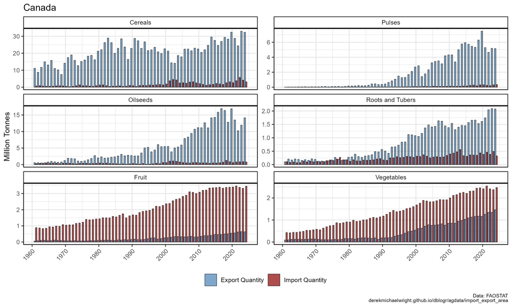

#### Crop Import/Export

**Crop Import/Export**

Graphs of of crop import/export using FAO data

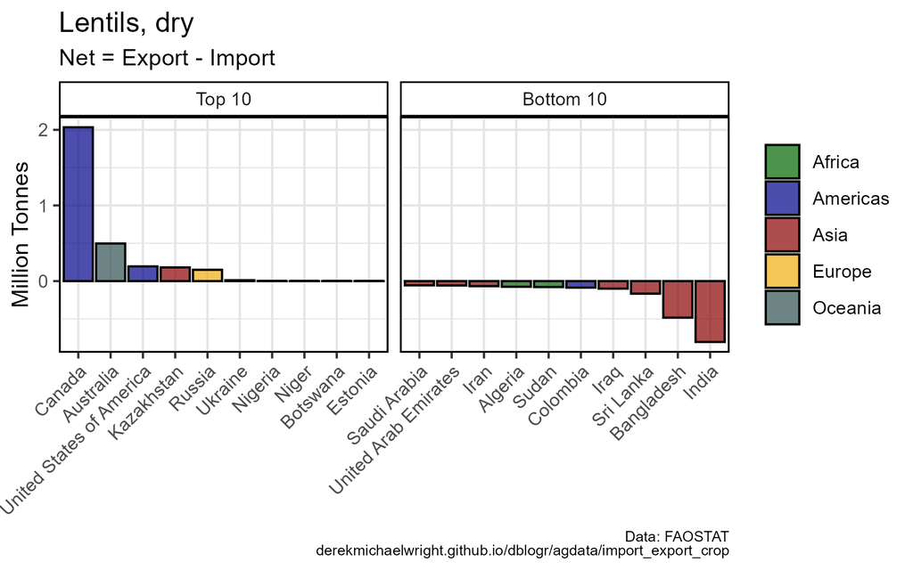